# Random graphs and the modelling of social networks

## Abstract

Random graphs are a branch of graph theory in mathematics, and represent graphs created using random processes. These have wide applications, including power grids, food webs, protein networks. Our main focus will however be on the modelling of social networks using random graphs. We shall first look at important properties of random graphs by introducing different models, and compare these with a sample network of Facebook. Finally, this report will introduce a new model devised by the presenter.

## What are Random Graphs?

Random graphs are graphs of nodes or vertices, which are connected by edges. These connections and nodes are generated either by following a random distribution, or a random process.

There are many different models that use different methods to create random graphs, to obtain different graphs with different properties.

## What properties do we want?

Different models are suited for different applications.

In our case, we focus on modelling social networks, thus we will be discussing the common characteristics that these networks display.

## The first model: Erdős–Rényi

The first and simplest of the random graphs.

The first model we will look at is the Erdős–Rényi model. This model requires two parameters, $n$ for the number of nodes, and $p$ for the probability of an edge existing between any two nodes independently. The expected total number of edges is therefore $p \times {n \choose 2}$, as ${n \choose 2}$ is the total possible number of edges that can be formed.

[figure not shown]

```python
n = 50
p = 0.1

g = erdos_renyi(n, p)
pos = nx.get_node_attributes(g, 'pos')
nx.draw(g, pos)
```

## Clustering

A commonly studied property of random graphs is the clustering coefficient. This is a measure to quantify how likely it is that, if you know two friends, the two of them would know each other.

Local clustering coefficient is the clustering coefficient for a specific node, $C_i$, and is calculated as the no. of existing edges between neighbouring nodes divided by the no. of potential edges between neighbouring nodes.

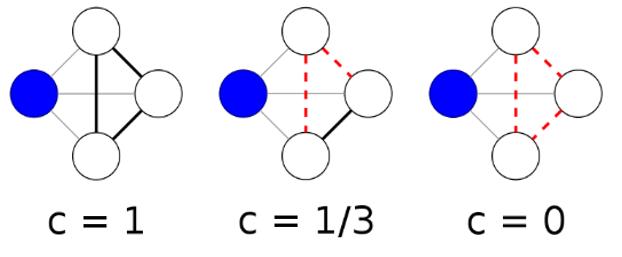

## The Big Picture

Now that we know what the local clustering coefficient is for a single node, we can apply this to the whole graph to get a macro view of its clustering.

One way to do this is by taking the mean of all the local clustering coefficients. Thus we arrive at $C_g = \sum_{i = 0} ^{n} \frac {C_i} {n}$

This is the average clustering coefficient.

## Average vs Global

Another commonly used measure for clustering is transitivity, or the global clustering coefficient. This is a weighted average of the local clustering coefficient, where each $C_i$ is multiplied by ${k_i} \choose {2}$, where $k_i$ is the degree of the node $i$, the number of nodes it is connected to.

Transitivity places more weight on higher degree nodes, which are commonly called "hubs", while the average clustering coefficient places equal weight on all nodes.

As such, while both average and global clustering coefficients would give an indication of clustering, using both would give greater insights to the distribution of the clustering.

## A Small Cluster

What would a graph with high clustering coefficient look like?

To create such a graph, a simple way would be to create a lattice like structure, by connecting nodes with their closest neighbours, throughout the entire graph.

```
Average clustering coefficient: 0.6
Global clustering coefficient: 0.6
```

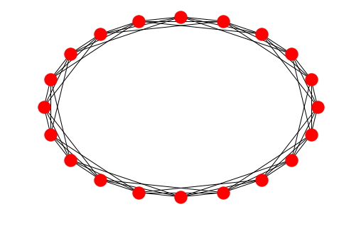

```python
n = 20
k = 6

g = high_clustering_graph(n, k)
pos = nx.get_node_attributes(g, 'pos')
nx.draw(g, pos)
print(f"Average clustering coefficient: {round(nx.average_clustering(g), 1)}")
print(f"Global clustering coefficient: {round(nx.transitivity(g), 1)}")
```

## It's a Small World

Researches often say that we live in a small world. This means that we can reach out to almost anyone in the world with just a few connections, famously known as the six degrees of separation.

Formally, small world behaviour in networks is characterised largely by high clustering and a low mean path distance. The path distance between two nodes is the smallest number of edges required to connect the two nodes.

We already have a high clustering graph in the previous slide. But how do we make a small world one now?

## Watts-Strogatz Model

Also called the small world model, this is a model meant to capture the key elements of a small world network.

The Watts-Strogatz Model requires 3 parameters, $n$ for the number of nodes, $k$, an even number, for the mean degree, and a special parameter $\beta$ where $0<\beta<1$. A graph of $n$ nodes is first created, with each node connected to $k/2$ nodes to their immediate left and right. Each edge in the graph is then rewired with probability $\beta$, and this is done so without duplication or self-looping.

As such, if $\beta$ is small, the bulk of the lattice structure is retained, and a few rewired edges are enough to significantly reduce the mean path distance.

```
Average clustering coefficient: 0.5
Global clustering coefficient: 0.5
Mean path distance: 1.932
```

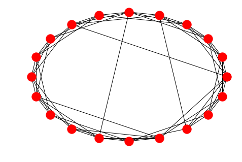

```python
n = 20
k = 6
beta = 0.2

g = watts_strogatz(n, k, beta)
pos = nx.get_node_attributes(g, 'pos')
nx.draw(g, pos)
print(f"Average clustering coefficient: {round(nx.average_clustering(g), 1)}")
print(f"Global clustering coefficient: {round(nx.transitivity(g), 1)}")
print(f"Mean path distance: {round(nx.average_shortest_path_length(g), 3)}")
```

## Degree Distributions

The degree of a node is the number of edges linked to it. The degree distribution of a graph is a histogram of the degrees of all the nodes in the graph.

[figure not shown]

## Scale-free degree distribution

For a social network however, a scale-free degree distribution is a key property. This means that the degree distribution follows a power law, and is skewed such that there is a very low number of hubs, and a much higher number of nodes with degree close to zero.

## Barabási-Albert Model

The Barabasi-Albert model uses two parameters, $n$ for the number of nodes, and $m$ for the number of edges per node. The model begins with $m$ nodes in an empty graph, and at each next step, a node is added, with m edges connected to other nodes. The probability of the new node being connected to a node is equal to the proportion of the degree of the node to the total degree of the graph.

```
Average clustering coefficient: 0.274
Global clustering coefficient: 0.228
Mean path distance: 2.008
```

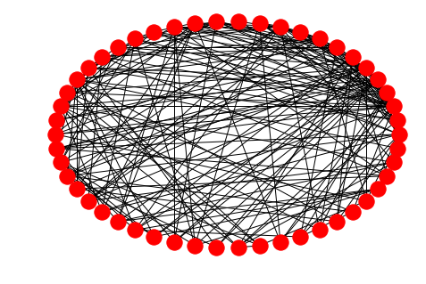

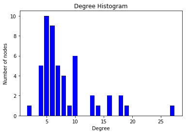

```python
n = 50
m = 5

g = barabasi_albert(n, m)
pos = nx.get_node_attributes(g, 'pos')
nx.draw(g, pos)
print(f"Average clustering coefficient: {round(nx.average_clustering(g), 3)}")
print(f"Global clustering coefficient: {round(nx.transitivity(g), 3)}")
print(f"Mean path distance: {round(nx.average_shortest_path_length(g), 3)}")
plt.show()
plt.clf()

# Drawing degree histogram
degree_sequence = sorted([d for n, d in g.degree()])
count = Counter(degree_sequence)

plt.bar(count.keys(), count.values(), width=0.80, color='b')
plt.title("Degree Histogram")
plt.xlabel("Degree")
plt.ylabel("Number of nodes")
plt.show()
```

## Scale-free small world

Now, we know the main ingredients we'll need for building a good model of a social network.

High clustering, low mean path distance, scale-free degree distribution. But so far our models don't have all of that at once.

Fortunately, we have another model that combines them both.

## Klemm-Eguíluz

This is a small-world and scale free model that is a crossover of a high clustering model and the Barabasi-Albert model.

1. It begins with a connected graph of $m$ number of active nodes, and a new node is added in each time step.
2. The new node has $m$ edges added to the $m$ active nodes, and each edge is decided, with probability $\mu$, that the edge is rewired to a random node according to linear preferential attachment.
3. The new node is then active, and a random node is deactivated, such that $m$ active nodes remain.

Thus, depending on $\mu$, the graph can be more of a high clustering model, or more like the Barabasi-Albert Model, essentially combining both models.

```
Average clustering coefficient: 0.583
Global clustering coefficient: 0.434
Mean path distance: 2.062
```

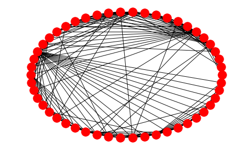

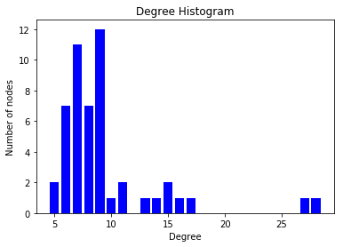

```python
n = 50
m = 5
mu = 0.1

g = klemm_eguiluz(n, m, mu)
pos = nx.get_node_attributes(g, 'pos')
nx.draw(g, pos)
print(f"Average clustering coefficient: {round(nx.average_clustering(g), 3)}")
print(f"Global clustering coefficient: {round(nx.transitivity(g), 3)}")
print(f"Mean path distance: {round(nx.average_shortest_path_length(g), 3)}")
plt.show()
plt.clf()

# Drawing degree histogram
degree_sequence = sorted([d for n, d in g.degree()])
count = Counter(degree_sequence)

plt.bar(count.keys(), count.values(), width=0.80, color='b')
plt.title("Degree Histogram")
plt.xlabel("Degree")
plt.ylabel("Number of nodes")
plt.show()
```

## Facebook

Now we are ready for our first round with a social network. We will be using data of a sample of Facebook collected by Stanford Network Analysis Project (SNAP), and comparing the models we have so far with it.

```
Name: Facebook
Type: Graph
Number of nodes: 4039
Number of edges: 88234
Average degree:  43.6910
Average clustering coefficient: 0.606
Global clustering coefficient: 0.519
Mean path distance: 3.693
```

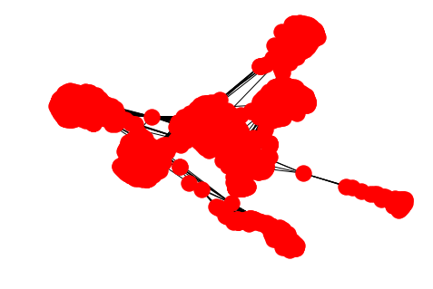

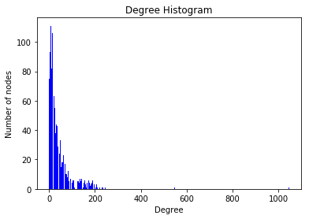

```python
g = nx.Graph()
with open("facebook_combined.txt") as f:
    edges = f.read().split("\n")
    edges.pop()
    edges = [tuple(map(int, edge.split(" "))) for edge in edges]
g.add_edges_from(edges)

nx.draw(g, node_size = 20)
g.name = "Facebook"
print(nx.info(g))
print(f"Average clustering coefficient: {round(nx.average_clustering(g), 3)}")
print(f"Global clustering coefficient: {round(nx.transitivity(g), 3)}")
print(f"Mean path distance: {round(nx.average_shortest_path_length(g), 3)}")
plt.show()
plt.clf()

# Drawing degree histogram
degree_sequence = sorted([d for n, d in g.degree()])
count = Counter(degree_sequence)

plt.bar(count.keys(), count.values(), width=0.80, color='b')
plt.title("Degree Histogram")
plt.xlabel("Degree")
plt.ylabel("Number of nodes")
plt.show()
```

## Facing Facebook

Obviously, our earliest models would not be able to model Facebook well, because they lack at least one of these properties. But how will the Klemm-Eguiluz model fare?

```
Name: Klemm-Eguiluz
Type: Graph
Number of nodes: 4039
Number of edges: 88605
Average degree:  43.8747
Average clustering coefficient: 0.601
Global clustering coefficient: 0.293
Mean path distance: 2.777
```

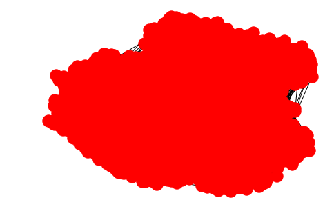

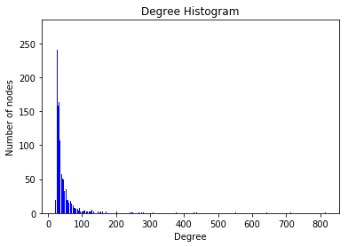

```python
n = 4039
m = 22
mu = 0.09

g = klemm_eguiluz(n, m, mu)
nx.draw(g, node_size = 20)
g.name = "Klemm-Eguiluz"
print(nx.info(g))
print(f"Average clustering coefficient: {round(nx.average_clustering(g), 3)}")
print(f"Global clustering coefficient: {round(nx.transitivity(g), 3)}")
print(f"Mean path distance: {round(nx.average_shortest_path_length(g), 3)}")
plt.show()
plt.clf()

# Drawing degree histogram
degree_sequence = sorted([d for n, d in g.degree()])
count = Counter(degree_sequence)

plt.bar(count.keys(), count.values(), width=0.80, color='b')
plt.title("Degree Histogram")
plt.xlabel("Degree")
plt.ylabel("Number of nodes")
plt.show()
```

Well it kind of met the main properties that we are looking for. A decent amount of clustering, nice mean path distance, and a scale-free degree distribution?

Although, looking at the degree distribution, it is clear that it looks quite different. The lowest degree node appears to have a degree of around 20, while Facebook's histogram starts at 0.

This is due to the way that the edges are added, with each node having $m$ connections to other nodes.

Apart from that, the graph itself is also noticeably different. While it is possible to split the nodes in Facebook into certain blocks, the Klemm-Eguiluz model looks like a giant mess.

## SIR

We might not be able to find perfect model for our social network yet, but let us see if it can act in a similar way to Facebook.

In social networks, data and information is constantly exchanged. People spread information to their friends, family, who spread it on to their friends and family, and so on.

To analyse this, we have the Susceptible-Infected-Recovered (SIR) Model. Nodes are in one of three states: susceptible, infected, or recovered. All nodes begin in the susceptible state. A few are infected, then at every time step, the neighbours of the infected nodes are infected with probability $p_1$, and the infected nodes recover with probability $p_2$. Once all the nodes are recovered, the model ends.

While the most common use of this is to model the spread of infectious diseases, we will apply this to our random graphs to analyse the spread of information.

```
SIR model of graph after 0 time steps:
```

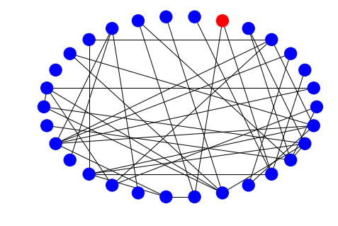

```python
g = erdos_renyi(30, 0.2)
p1, p2, p_init = 0.8, 0.3, 0.1

i_plot, r_plot, s_plot, state, t = sir_init(g, p1, p2, p_init)
```

```
SIR model of graph after 1 time steps:
```

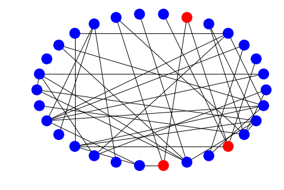

```python
state, t = sir_step(state, t)
```

```
SIR model of graph after 2 time steps:
```

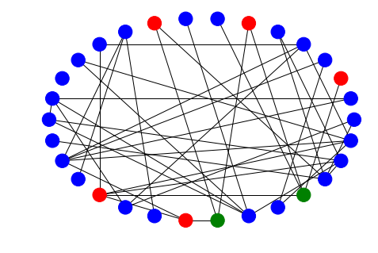

```python
state, t = sir_step(state, t)
```

```
SIR model of graph after 3 time steps:
```

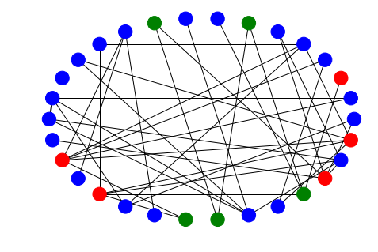

```python
state, t = sir_step(state, t)
```

```
SIR model of graph after 4 time steps:
```

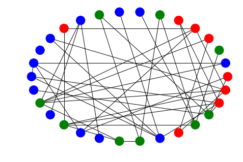

```python
state, t = sir_step(state, t)
```

```
SIR model of graph after 5 time steps:
```

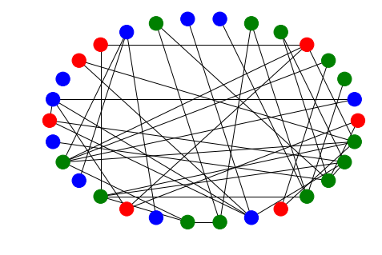

```python
state, t = sir_step(state, t)
```

```
SIR model of graph after 6 time steps:
```

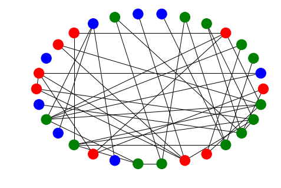

```python
state, t = sir_step(state, t)
```

```
SIR model of graph after 7 time steps:
```

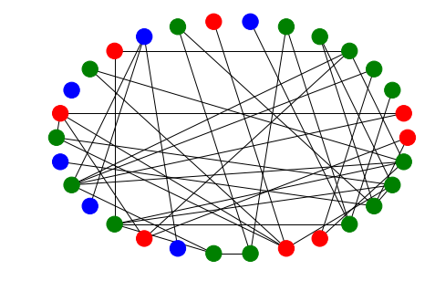

```python
state, t = sir_step(state, t)
```

```
SIR model of graph after 8 time steps:
```

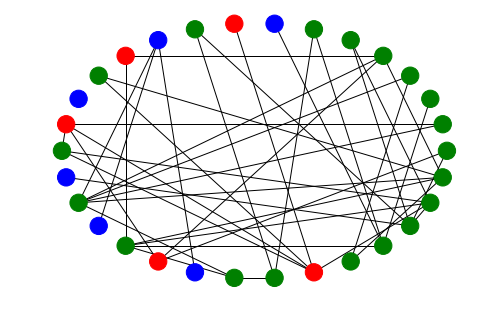

```python
state, t = sir_step(state, t)
```

```
SIR model of graph after 9 time steps:
```

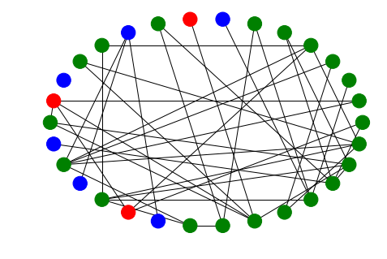

```python
state, t = sir_step(state, t)
```

```
SIR model of graph after 10 time steps:
```

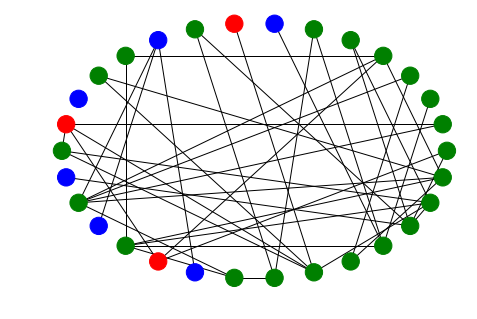

```python
state, t = sir_step(state, t)
```

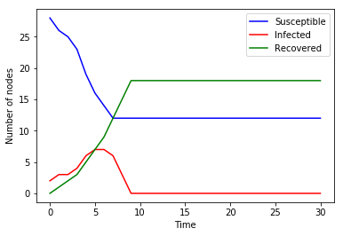

```python
sir_plot(g, p1, p2, p_init, 30)
```